# PREDICTING COMPRESSIVE STRENGTH OF CONCRETE | FEATURIZATION | MODEL SELECTION | TUNING

Concrete is the most important material in civil engineering. The concrete compressive strength is a highly nonlinear function of age and ingredients. These ingredients include cement, blast furnace slag, fly ash, water, superplasticizer, coarse aggregate, and fine aggregate.

This modeling efffort uses the concrete mix data provided herewith and tries to predict the strength of high performance concrete using Machine Learning.

## OBJECTIVE

Objective is to build a ML model, learning using historical data and modeling for predicting the strength of high performance concrete. Feature Engineering techniques will be used to determine the optimal set of concrete data features

## Data Description

The actual concrete compressive strength (MPa) for a given mixture under a specific age (days) was determined from laboratory. Data is in raw form (not scaled). The data has 8 quantitative input variables, and 1 quantitative output variable, and 1030 instances (observations).

#### Attribute Information

Cement : measured in kg in a m3 mixture

Blast : measured in kg in a m3 mixture

Fly ash : measured in kg in a m3 mixture

Water : measured in kg in a m3 mixture

Superplasticizer : measured in kg in a m3 mixture

Coarse Aggregate : measured in kg in a m3 mixture

Fine Aggregate : measured in kg in a m3 mixture

Age : day (1~365)

Concrete compressive strength measured in MPa

## IMPORT THE NECESSARY LIBARIES

```python
import numpy as np # linear algebra
import pandas as pd # data processing, CSV file I/O (e.g. pd.read_csv)
#importing ploting libraries
import matplotlib.pyplot as plt
#importing seaborn for statistical plots
import seaborn as sns
#setting styling figures
plt.rc('font',size=14)
sns.set(style='white')
sns.set(style='whitegrid',color_codes=True)
#To enable plotting graphs in Jupyter notebook
%matplotlib inline
#importing the feature scaling library
from sklearn.preprocessing import StandardScaler
#Import Sklearn package's data splitting function which is based on random function
from sklearn.model_selection import train_test_split
# Import Linear Regression, Ridge and Lasso machine learning library
from sklearn.linear_model import LinearRegression, Ridge, Lasso
# Import KNN Regressor machine learning library
from sklearn.neighbors import KNeighborsRegressor
# Import Decision Tree Regressor machine learning library
from sklearn.tree import DecisionTreeRegressor
# Import ensemble machine learning library
from sklearn.ensemble import (RandomForestRegressor, GradientBoostingRegressor,AdaBoostRegressor,BaggingRegressor)
# Import support vector regressor machine learning library
from sklearn.svm import SVR
#Import the metrics
from sklearn import metrics
#Import the Voting regressor for Ensemble
from sklearn.ensemble import VotingRegressor
# Import stats from scipy
from scipy import stats
# Import zscore for scaling
from scipy.stats import zscore
#importing the metrics
from sklearn.metrics import mean_squared_error,mean_absolute_error,r2_score
#importing the K fold
from sklearn.model_selection import KFold
#importing the cross validation score
from sklearn.model_selection import cross_val_score
#importing the preprocessing library
from sklearn import preprocessing
# importing the Polynomial features
from sklearn.preprocessing import PolynomialFeatures
#importing kmeans clustering library
from sklearn.cluster import KMeans
from sklearn.utils import resample
```

## 1. LOAD THE DATA SET

```python
concrete_df = pd.read_csv('concrete.csv')
```

## 2. EYEBALL THE RAW DATA

We will review the dataset for dimension, column description and ensure that all attributes are understood well.

```python
# Display the first 10 records
concrete_df.head(10)
```

|  | cement | slag | ash | water | superplastic | coarseagg | fineagg | age | strength |
| --- | --- | --- | --- | --- | --- | --- | --- | --- | --- |
| 0 | 141.3 | 212.0 | 0.0 | 203.5 | 0.0 | 971.8 | 748.5 | 28 | 29.89 |
| 1 | 168.9 | 42.2 | 124.3 | 158.3 | 10.8 | 1080.8 | 796.2 | 14 | 23.51 |
| 2 | 250.0 | 0.0 | 95.7 | 187.4 | 5.5 | 956.9 | 861.2 | 28 | 29.22 |
| 3 | 266.0 | 114.0 | 0.0 | 228.0 | 0.0 | 932.0 | 670.0 | 28 | 45.85 |
| 4 | 154.8 | 183.4 | 0.0 | 193.3 | 9.1 | 1047.4 | 696.7 | 28 | 18.29 |
| 5 | 255.0 | 0.0 | 0.0 | 192.0 | 0.0 | 889.8 | 945.0 | 90 | 21.86 |
| 6 | 166.8 | 250.2 | 0.0 | 203.5 | 0.0 | 975.6 | 692.6 | 7 | 15.75 |
| 7 | 251.4 | 0.0 | 118.3 | 188.5 | 6.4 | 1028.4 | 757.7 | 56 | 36.64 |
| 8 | 296.0 | 0.0 | 0.0 | 192.0 | 0.0 | 1085.0 | 765.0 | 28 | 21.65 |
| 9 | 155.0 | 184.0 | 143.0 | 194.0 | 9.0 | 880.0 | 699.0 | 28 | 28.99 |

```python
# Review the shape of the data
concrete_df.shape
```

```
(1030, 9)
```

```python
# # Display information about the dataframe for data type of each of the variable, number of values entered in each of the variables
concrete_df.info()
```

```
<class 'pandas.core.frame.DataFrame'>
RangeIndex: 1030 entries, 0 to 1029
Data columns (total 9 columns):
 #   Column        Non-Null Count  Dtype
---  ------        --------------  -----
 0   cement        1030 non-null   float64
 1   slag          1030 non-null   float64
 2   ash           1030 non-null   float64
 3   water         1030 non-null   float64
 4   superplastic  1030 non-null   float64
 5   coarseagg     1030 non-null   float64
 6   fineagg       1030 non-null   float64
 7   age           1030 non-null   int64
 8   strength      1030 non-null   float64
dtypes: float64(8), int64(1)
memory usage: 72.5 KB
```

```python
# Check for missing values in the dataset
concrete_df.isnull().sum()
```

```
cement          0
slag            0
ash             0
water           0
superplastic    0
coarseagg       0
fineagg         0
age             0
strength        0
dtype: int64
```

```python
# Check for negative values in the dataset
concrete_df.iloc[:,1:].lt(0).sum()
```

```
slag            0
ash             0
water           0
superplastic    0
coarseagg       0
fineagg         0
age             0
strength        0
dtype: int64
```

```python
# 5-Point Summary
concrete_df.describe()
```

|  | cement | slag | ash | water | superplastic | coarseagg | fineagg | age | strength |
| --- | --- | --- | --- | --- | --- | --- | --- | --- | --- |
| count | 1030.000000 | 1030.000000 | 1030.000000 | 1030.000000 | 1030.000000 | 1030.000000 | 1030.000000 | 1030.000000 | 1030.000000 |
| mean | 281.167864 | 73.895825 | 54.188350 | 181.567282 | 6.204660 | 972.918932 | 773.580485 | 45.662136 | 35.817961 |
| std | 104.506364 | 86.279342 | 63.997004 | 21.354219 | 5.973841 | 77.753954 | 80.175980 | 63.169912 | 16.705742 |
| min | 102.000000 | 0.000000 | 0.000000 | 121.800000 | 0.000000 | 801.000000 | 594.000000 | 1.000000 | 2.330000 |
| 25% | 192.375000 | 0.000000 | 0.000000 | 164.900000 | 0.000000 | 932.000000 | 730.950000 | 7.000000 | 23.710000 |
| 50% | 272.900000 | 22.000000 | 0.000000 | 185.000000 | 6.400000 | 968.000000 | 779.500000 | 28.000000 | 34.445000 |
| 75% | 350.000000 | 142.950000 | 118.300000 | 192.000000 | 10.200000 | 1029.400000 | 824.000000 | 56.000000 | 46.135000 |
| max | 540.000000 | 359.400000 | 200.100000 | 247.000000 | 32.200000 | 1145.000000 | 992.600000 | 365.000000 | 82.600000 |

```python
# Check for duplicate rows in the dataset
duplicateDFRow = concrete_df[concrete_df.duplicated()]
print("Duplicate Rows except first occurrence based on all columns are :")
duplicateDFRow.sort_values(['cement','slag', 'ash', 'water', 'superplastic', 'coarseagg', 'fineagg', 'age'])
```

```
Duplicate Rows except first occurrence based on all columns are :
```

|  | cement | slag | ash | water | superplastic | coarseagg | fineagg | age | strength |
| --- | --- | --- | --- | --- | --- | --- | --- | --- | --- |
| 468 | 252.0 | 0.0 | 0.0 | 185.0 | 0.0 | 1111.0 | 784.0 | 28 | 19.69 |
| 400 | 362.6 | 189.0 | 0.0 | 164.9 | 11.6 | 944.7 | 755.8 | 3 | 35.30 |
| 420 | 362.6 | 189.0 | 0.0 | 164.9 | 11.6 | 944.7 | 755.8 | 3 | 35.30 |
| 943 | 362.6 | 189.0 | 0.0 | 164.9 | 11.6 | 944.7 | 755.8 | 3 | 35.30 |
| 576 | 362.6 | 189.0 | 0.0 | 164.9 | 11.6 | 944.7 | 755.8 | 7 | 55.90 |
| 933 | 362.6 | 189.0 | 0.0 | 164.9 | 11.6 | 944.7 | 755.8 | 7 | 55.90 |
| 525 | 362.6 | 189.0 | 0.0 | 164.9 | 11.6 | 944.7 | 755.8 | 28 | 71.30 |
| 738 | 362.6 | 189.0 | 0.0 | 164.9 | 11.6 | 944.7 | 755.8 | 28 | 71.30 |
| 967 | 362.6 | 189.0 | 0.0 | 164.9 | 11.6 | 944.7 | 755.8 | 28 | 71.30 |
| 463 | 362.6 | 189.0 | 0.0 | 164.9 | 11.6 | 944.7 | 755.8 | 56 | 77.30 |
| 604 | 362.6 | 189.0 | 0.0 | 164.9 | 11.6 | 944.7 | 755.8 | 56 | 77.30 |
| 892 | 362.6 | 189.0 | 0.0 | 164.9 | 11.6 | 944.7 | 755.8 | 56 | 77.30 |
| 493 | 362.6 | 189.0 | 0.0 | 164.9 | 11.6 | 944.7 | 755.8 | 91 | 79.30 |
| 733 | 362.6 | 189.0 | 0.0 | 164.9 | 11.6 | 944.7 | 755.8 | 91 | 79.30 |
| 766 | 362.6 | 189.0 | 0.0 | 164.9 | 11.6 | 944.7 | 755.8 | 91 | 79.30 |
| 278 | 425.0 | 106.3 | 0.0 | 153.5 | 16.5 | 852.1 | 887.1 | 3 | 33.40 |
| 298 | 425.0 | 106.3 | 0.0 | 153.5 | 16.5 | 852.1 | 887.1 | 3 | 33.40 |
| 830 | 425.0 | 106.3 | 0.0 | 153.5 | 16.5 | 852.1 | 887.1 | 7 | 49.20 |
| 884 | 425.0 | 106.3 | 0.0 | 153.5 | 16.5 | 852.1 | 887.1 | 7 | 49.20 |
| 577 | 425.0 | 106.3 | 0.0 | 153.5 | 16.5 | 852.1 | 887.1 | 28 | 60.29 |
| 992 | 425.0 | 106.3 | 0.0 | 153.5 | 16.5 | 852.1 | 887.1 | 28 | 60.29 |
| 517 | 425.0 | 106.3 | 0.0 | 153.5 | 16.5 | 852.1 | 887.1 | 56 | 64.30 |
| 880 | 425.0 | 106.3 | 0.0 | 153.5 | 16.5 | 852.1 | 887.1 | 56 | 64.30 |
| 482 | 425.0 | 106.3 | 0.0 | 153.5 | 16.5 | 852.1 | 887.1 | 91 | 65.20 |
| 527 | 425.0 | 106.3 | 0.0 | 153.5 | 16.5 | 852.1 | 887.1 | 91 | 65.20 |

```python
# Count of duplicate rows in the dataset
duplicateDFRow.shape[0]
```

```
25
```

```python
#Checking for concrete data distribution based on 'age' of concrete mix setting
concrete_df.age = concrete_df.age.astype('category')
concrete_df.age.value_counts()
```

```
28     425
3      134
7      126
56      91
14      62
90      54
100     52
180     26
91      22
365     14
270     13
360      6
120      3
1        2
Name: age, dtype: int64
```

```python
concrete_df.age = concrete_df.age.astype('int')
```

#### Profile Report (Observations)

The Concrete data set is a multivariate data.

There are 1030 Observations/Rows and 9 material Attributes/Columns

The dataset contains concrete material mixture setting for age between '1' and '365' days

There are no missing values in the dataset

There are no negative values in the dataset

The dataset contains 9 quantitative numeric variables of which are 8 are input varaibles and 'strength' is the target variable.

That is there are eight independent variables (cement, slag, ash, water, superplastic, coarseagg, fineagg, age) and one dependent variable (strength).

The concrete mix data distribution based on feature 'age' is highly imbalanced. Data contains larger number of observations (almost 42%) for an 'age' of 28 days.

Looking at the 5-point summary values across all the features, the scale of some of the attributes are largely different from each other. Hence we will need to do Feature scaling prior to modeling.

## 3. EXPLORATORY DATA ANALYSIS

In this section we will conduct:

Univariate Analysis

Bi-Variate Analysis

Outlier Treatment

### a. UNIVARIATE ANALYSIS

We will study data types and description of the independent attributes including name, meaning, range of values observed, central values (mean and median),standard deviation and quartiles, analysis of the body of distributions / tails, missing values, outliers of the concrete dataset and review their data distribution.

### Cement

```python
# Range of values of Attribute Cement
print('Range of values for Attribute Cement: ', concrete_df['cement'].max()-concrete_df['cement'].min())
```

```
Range of values for Attribute Cement:  438.0
```

```python
# Central Values of the Attribute 'Cement' is indicated by the 5-Point Summary.
concrete_df['cement'].describe()
```

```
count    1030.000000
mean      281.167864
std       104.506364
min       102.000000
25%       192.375000
50%       272.900000
75%       350.000000
max       540.000000
Name: cement, dtype: float64
```

```python
# Quartiles of Attribute Cement
Q1=concrete_df['cement'].quantile(0.25)
Q3=concrete_df['cement'].quantile(0.75)
print('1st Quartile (Q1) is: ', Q1)
print('3st Quartile (Q3) is: ', Q3)
print('Interquartile range (IQR) is ', Q3-Q1)
```

```
1st Quartile (Q1) is:  192.375
3st Quartile (Q3) is:  350.0
Interquartile range (IQR) is  157.625
```

```python
# Outlier detection of Attribute Cement from Interquartile range (IQR)
# IQR=Q3-Q1
#lower 1.5*IQR whisker i.e Q1-1.5*IQR
#upper 1.5*IQR whisker i.e Q3+1.5*IQR
L1 = Q1-1.5*(Q3-Q1)
U1 = Q3+1.5*(Q3-Q1)
print('Upper outlier in cement(U1): ', U1)
print('Lower outlier in cement(L1): ', L1)
print('Number of outliers in cement above U1 : ', concrete_df[concrete_df['cement']>586.4375]['cement'].count())
print('Number of outliers in cement below L1 : ', concrete_df[concrete_df['cement']<-44.0625]['cement'].count())
print('% of Upper Outliers: ',round(concrete_df[concrete_df['cement']>586.4375]['cement'].count()*100/len(concrete_df)), '%')
print('% of Lower Outliers:',round(concrete_df[concrete_df['cement']<-44.0625]['cement'].count()*100/len(concrete_df)), '%')
```

```
Upper outlier in cement(U1):  586.4375
Lower outlier in cement(L1):  -44.0625
Number of outliers in cement above U1 :  0
Number of outliers in cement below L1 :  0
% of Upper Outliers:  0.0 %
% of Lower Outliers: 0.0 %
```

```python
# Analyzing the Univariate distribution of cement, quartiles, whiskers, any outliers present and
# target value distribution of cement vs strength.
```

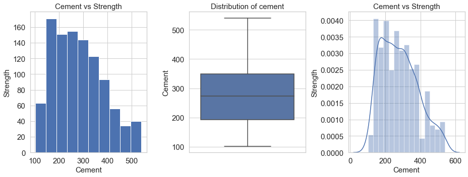

```python
fig, (ax1,ax2,ax3)=plt.subplots(1,3,figsize=(13,5))

#histogram
ax1.hist(concrete_df['cement'])
ax1.set_xlabel('Cement', fontsize=15)
ax1.set_ylabel('Strength', fontsize=15)
ax1.set_title('Cement vs Strength', fontsize=15)
ax1.tick_params(labelsize=15)

#boxplot
sns.boxplot(x='cement',data=concrete_df,orient='v',ax=ax2)
ax2.set_ylabel('Cement', fontsize=15)
ax2.set_title('Distribution of cement', fontsize=15)
ax2.tick_params(labelsize=15)

#distplot
sns.distplot(concrete_df['cement'],ax=ax3)
ax3.set_xlabel('Cement', fontsize=15)
ax3.set_ylabel('Strength', fontsize=15)
ax3.set_title('Cement vs Strength', fontsize=15)
ax3.tick_params(labelsize=15)

plt.subplots_adjust(wspace=0.5)
plt.tight_layout()
```

### Slag

```python
# Range of values of Attribute Slag
print('Range of values for Attribute Slag: ', concrete_df['slag'].max()-concrete_df['slag'].min())
```

```
Range of values for Attribute Slag:  359.4
```

```python
# Central Values of the Attribute 'Slag' is indicated by the 5-Point Summary.
concrete_df['slag'].describe()
```

```
count    1030.000000
mean       73.895825
std        86.279342
min         0.000000
25%         0.000000
50%        22.000000
75%       142.950000
max       359.400000
Name: slag, dtype: float64
```

```python
# Quartiles of Attribute Slag
Q1=concrete_df['slag'].quantile(0.25)
Q3=concrete_df['slag'].quantile(0.75)
print('1st Quartile (Q1) is: ', Q1)
print('3st Quartile (Q3) is: ', Q3)
print('Interquartile range (IQR) is ', Q3-Q1)
```

```
1st Quartile (Q1) is:  0.0
3st Quartile (Q3) is:  142.95
Interquartile range (IQR) is  142.95
```

```python
# Outlier detection of Attribute Slag from Interquartile range (IQR)
# IQR=Q3-Q1
#lower 1.5*IQR whisker i.e Q1-1.5*IQR
#upper 1.5*IQR whisker i.e Q3+1.5*IQR
L1 = Q1-1.5*(Q3-Q1)
U1 = Q3+1.5*(Q3-Q1)
print('Upper outlier in Slag(U1): ', U1)
print('Lower outlier in Slag(L1): ', L1)
print('Number of outliers in Slag above U1 : ', concrete_df[concrete_df['slag']>357.375]['slag'].count())
print('Number of outliers in Slag below L1 : ', concrete_df[concrete_df['slag']<-214.425]['slag'].count())
print('% of Upper Outliers: ',concrete_df[concrete_df['slag']>357.375]['slag'].count()*100/len(concrete_df), '%')
print('% of Lower Outliers:',concrete_df[concrete_df['slag']<-214.425]['slag'].count()*100/len(concrete_df), '%')
```

```
Upper outlier in Slag(U1):  357.375
Lower outlier in Slag(L1):  -214.42499999999998
Number of outliers in Slag above U1 :  2
Number of outliers in Slag below L1 :  0
% of Upper Outliers:  0.1941747572815534 %
% of Lower Outliers: 0.0 %
```

```python
# Analyzing the Univariate distribution of Slag, quartiles, whiskers, any outliers present and
# target value distribution of Slag vs strength.
```

[figure not shown]

```python
fig, (ax1,ax2,ax3)=plt.subplots(1,3,figsize=(13,5))

#histogram
ax1.hist(concrete_df['slag'])
ax1.set_xlabel('Slag', fontsize=15)
ax1.set_ylabel('Strength', fontsize=15)
ax1.set_title('Slag vs Strength', fontsize=15)
ax1.tick_params(labelsize=15)

#boxplot
sns.boxplot(x='cement',data=concrete_df,orient='v',ax=ax2)
ax2.set_ylabel('Slag', fontsize=15)
ax2.set_title('Distribution of Slag', fontsize=15)
ax2.tick_params(labelsize=15)

#distplot
sns.distplot(concrete_df['cement'],ax=ax3)
ax3.set_xlabel('Slag', fontsize=15)
ax3.set_ylabel('Strength', fontsize=15)
ax3.set_title('Slag vs Strength', fontsize=15)
ax3.tick_params(labelsize=15)

plt.subplots_adjust(wspace=0.5)
plt.tight_layout()
```

### Ash

```python
# Range of values of Attribute Ash
print('Range of values for Attribute Ash: ', concrete_df['ash'].max()-concrete_df['ash'].min())
```

```
Range of values for Attribute Ash:  200.1
```

```python
# Central Values of the Attribute 'Ash' is indicated by the 5-Point Summary.
concrete_df['ash'].describe()
```

```
count    1030.000000
mean       54.188350
std        63.997004
min         0.000000
25%         0.000000
50%         0.000000
75%       118.300000
max       200.100000
Name: ash, dtype: float64
```

```python
# Quartiles of Attribute Ash
Q1=concrete_df['ash'].quantile(0.25)
Q3=concrete_df['ash'].quantile(0.75)
print('1st Quartile (Q1) is: ', Q1)
print('3st Quartile (Q3) is: ', Q3)
print('Interquartile range (IQR) is ', Q3-Q1)
```

```
1st Quartile (Q1) is:  0.0
3st Quartile (Q3) is:  118.3
Interquartile range (IQR) is  118.3
```

```python
# Outlier detection of Attribute Ash from Interquartile range (IQR)
# IQR=Q3-Q1
#lower 1.5*IQR whisker i.e Q1-1.5*IQR
#upper 1.5*IQR whisker i.e Q3+1.5*IQR
L1 = Q1-1.5*(Q3-Q1)
U1 = Q3+1.5*(Q3-Q1)
print('Upper outlier in Ash(U1): ', U1)
print('Lower outlier in Ash(L1): ', L1)
print('Number of outliers in Ash above U1 : ', concrete_df[concrete_df['ash']>295.75]['ash'].count())
print('Number of outliers in Ash below L1 : ', concrete_df[concrete_df['ash']<-177.45]['ash'].count())
print('% of Upper Outliers: ',round(concrete_df[concrete_df['ash']>295.75]['ash'].count()*100/len(concrete_df)), '%')
print('% of Lower Outliers:',round(concrete_df[concrete_df['ash']<-177.45]['ash'].count()*100/len(concrete_df)), '%')
```

```
Upper outlier in Ash(U1):  295.75
Lower outlier in Ash(L1):  -177.45
Number of outliers in Ash above U1 :  0
Number of outliers in Ash below L1 :  0
% of Upper Outliers:  0.0 %
% of Lower Outliers: 0.0 %
```

```python
# Analyzing the Univariate distribution of Ash, quartiles, whiskers, any outliers present and
# target value distribution of Ash vs strength.
```

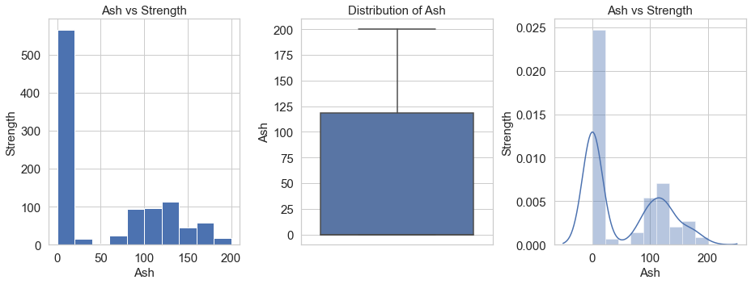

```python
fig, (ax1,ax2,ax3)=plt.subplots(1,3,figsize=(13,5))

#histogram
ax1.hist(concrete_df['ash'])
ax1.set_xlabel('Ash', fontsize=15)
ax1.set_ylabel('Strength', fontsize=15)
ax1.set_title('Ash vs Strength', fontsize=15)
ax1.tick_params(labelsize=15)

#boxplot
sns.boxplot(x='ash',data=concrete_df,orient='v',ax=ax2)
ax2.set_ylabel('Ash', fontsize=15)
ax2.set_title('Distribution of Ash', fontsize=15)
ax2.tick_params(labelsize=15)

#distplot
sns.distplot(concrete_df['ash'],ax=ax3)
ax3.set_xlabel('Ash', fontsize=15)
ax3.set_ylabel('Strength', fontsize=15)
ax3.set_title('Ash vs Strength', fontsize=15)
ax3.tick_params(labelsize=15)

plt.subplots_adjust(wspace=0.5)
plt.tight_layout()
```

### Water

```python
# Range of values of Attribute Water
print('Range of values for Attribute Water: ', concrete_df['water'].max()-concrete_df['water'].min())
```

```
Range of values for Attribute Water:  125.2
```

```python
# Central Values of the Attribute 'Water' is indicated by the 5-Point Summary.
concrete_df['water'].describe()
```

```
count    1030.000000
mean      181.567282
std        21.354219
min       121.800000
25%       164.900000
50%       185.000000
75%       192.000000
max       247.000000
Name: water, dtype: float64
```

```python
# Quartiles of Attribute Water
Q1=concrete_df['water'].quantile(0.25)
Q3=concrete_df['water'].quantile(0.75)
print('1st Quartile (Q1) is: ', Q1)
print('3st Quartile (Q3) is: ', Q3)
print('Interquartile range (IQR) is ', Q3-Q1)
```

```
1st Quartile (Q1) is:  164.9
3st Quartile (Q3) is:  192.0
Interquartile range (IQR) is  27.099999999999994
```

```python
# Outlier detection of Attribute Water from Interquartile range (IQR)
# IQR=Q3-Q1
#lower 1.5*IQR whisker i.e Q1-1.5*IQR
#upper 1.5*IQR whisker i.e Q3+1.5*IQR
L1 = Q1-1.5*(Q3-Q1)
U1 = Q3+1.5*(Q3-Q1)
print('Upper outlier in Water(U1): ', U1)
print('Lower outlier in Water(L1): ', L1)
print('Number of outliers in Water above U1 : ', concrete_df[concrete_df['water'] > 232.64]['water'].count())
print('Number of outliers in Water below L1 : ', concrete_df[concrete_df['water'] < 124.25]['water'].count())
print('% of Upper Outliers: ',round(concrete_df[concrete_df['water'] > 232.64]['water'].count()*100/len(concrete_df)), '%')
print('% of Lower Outliers:',round(concrete_df[concrete_df['water'] < 124.25 ]['water'].count()*100/len(concrete_df)), '%')
```

```
Upper outlier in Water(U1):  232.64999999999998
Lower outlier in Water(L1):  124.25000000000001
Number of outliers in Water above U1 :  4
Number of outliers in Water below L1 :  5
% of Upper Outliers:  0.0 %
% of Lower Outliers: 0.0 %
```

```python
# Analyzing the Univariate distribution of Water, quartiles, whiskers, any outliers present and
# target value distribution of Water vs strength.
```

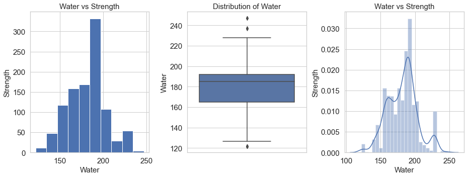

```python
fig, (ax1,ax2,ax3)=plt.subplots(1,3,figsize=(13,5))

#histogram
ax1.hist(concrete_df['water'])
ax1.set_xlabel('Water', fontsize=15)
ax1.set_ylabel('Strength', fontsize=15)
ax1.set_title('Water vs Strength', fontsize=15)
ax1.tick_params(labelsize=15)

#boxplot
sns.boxplot(x='water',data=concrete_df,orient='v',ax=ax2)
ax2.set_ylabel('Water', fontsize=15)
ax2.set_title('Distribution of Water', fontsize=15)
ax2.tick_params(labelsize=15)

#distplot
sns.distplot(concrete_df['water'],ax=ax3)
ax3.set_xlabel('Water', fontsize=15)
ax3.set_ylabel('Strength', fontsize=15)
ax3.set_title('Water vs Strength', fontsize=15)
ax3.tick_params(labelsize=15)

plt.subplots_adjust(wspace=0.5)
plt.tight_layout()
```

### Coarseagg

```python
# Range of values of Attribute Coarseagg
print('Range of values for Attribute Coarseagg: ', concrete_df['coarseagg'].max()-concrete_df['coarseagg'].min())
```

```
Range of values for Attribute Coarseagg:  344.0
```

```python
# Central Values of the Attribute 'Coarseagg' is indicated by the 5-Point Summary.
concrete_df['coarseagg'].describe()
```

```
count    1030.000000
mean      972.918932
std        77.753954
min       801.000000
25%       932.000000
50%       968.000000
75%      1029.400000
max      1145.000000
Name: coarseagg, dtype: float64
```

```python
# Quartiles of Attribute Coarseagg
Q1=concrete_df['coarseagg'].quantile(0.25)
Q3=concrete_df['coarseagg'].quantile(0.75)
print('1st Quartile (Q1) is: ', Q1)
print('3st Quartile (Q3) is: ', Q3)
print('Interquartile range (IQR) is ', Q3-Q1)
```

```
1st Quartile (Q1) is:  932.0
3st Quartile (Q3) is:  1029.4
Interquartile range (IQR) is  97.40000000000009
```

```python
# Outlier detection of Attribute Coarseagg from Interquartile range (IQR)
# IQR=Q3-Q1
#lower 1.5*IQR whisker i.e Q1-1.5*IQR
#upper 1.5*IQR whisker i.e Q3+1.5*IQR
L1 = Q1-1.5*(Q3-Q1)
U1 = Q3+1.5*(Q3-Q1)
print('Upper outlier in Coarseagg(U1): ', U1)
print('Lower outlier in Coarseagg(L1): ', L1)
print('Number of outliers in Coarseagg above U1 : ', concrete_df[concrete_df['coarseagg'] > 1175.5]['coarseagg'].count())
print('Number of outliers in Coarseagg below L1 : ', concrete_df[concrete_df['coarseagg'] < 785]['coarseagg'].count())
print('% of Upper Outliers: ',round(concrete_df[concrete_df['coarseagg'] > 1175.5]['coarseagg'].count()*100/len(concrete_df)), '%')
print('% of Lower Outliers:',round(concrete_df[concrete_df['coarseagg'] < 785]['coarseagg'].count()*100/len(concrete_df)), '%')
```

```
Upper outlier in Coarseagg(U1):  1175.5000000000002
Lower outlier in Coarseagg(L1):  785.8999999999999
Number of outliers in Coarseagg above U1 :  0
Number of outliers in Coarseagg below L1 :  0
% of Upper Outliers:  0.0 %
% of Lower Outliers: 0.0 %
```

```python
# Analyzing the Univariate distribution of Coarseagg, quartiles, whiskers, any outliers present and
# target value distribution of Coarseagg vs strength.
```

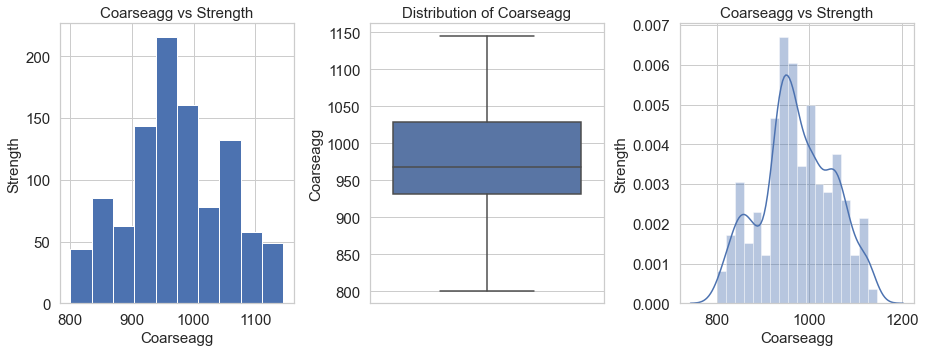

```python
fig, (ax1,ax2,ax3)=plt.subplots(1,3,figsize=(13,5))

#histogram
ax1.hist(concrete_df['coarseagg'])
ax1.set_xlabel('Coarseagg', fontsize=15)
ax1.set_ylabel('Strength', fontsize=15)
ax1.set_title('Coarseagg vs Strength', fontsize=15)
ax1.tick_params(labelsize=15)

#boxplot
sns.boxplot(x='coarseagg',data=concrete_df,orient='v',ax=ax2)
ax2.set_ylabel('Coarseagg', fontsize=15)
ax2.set_title('Distribution of Coarseagg', fontsize=15)
ax2.tick_params(labelsize=15)

#distplot
sns.distplot(concrete_df['coarseagg'],ax=ax3)
ax3.set_xlabel('Coarseagg', fontsize=15)
ax3.set_ylabel('Strength', fontsize=15)
ax3.set_title('Coarseagg vs Strength', fontsize=15)
ax3.tick_params(labelsize=15)

plt.subplots_adjust(wspace=0.5)
plt.tight_layout()
```

### Superplastic

```python
# Range of values of Attribute Superplastic
print('Range of values for Attribute Superplastic: ', concrete_df['superplastic'].max()-concrete_df['superplastic'].min())
```

```
Range of values for Attribute Superplastic:  32.2
```

```python
# Central Values of the Attribute 'Superplastic' is indicated by the 5-Point Summary.
concrete_df['superplastic'].describe()
```

```
count    1030.000000
mean        6.204660
std         5.973841
min         0.000000
25%         0.000000
50%         6.400000
75%        10.200000
max        32.200000
Name: superplastic, dtype: float64
```

```python
# Quartiles of Attribute Superplastic
Q1=concrete_df['superplastic'].quantile(0.25)
Q3=concrete_df['superplastic'].quantile(0.75)
print('1st Quartile (Q1) is: ', Q1)
print('3st Quartile (Q3) is: ', Q3)
print('Interquartile range (IQR) is ', Q3-Q1)
```

```
1st Quartile (Q1) is:  0.0
3st Quartile (Q3) is:  10.2
Interquartile range (IQR) is  10.2
```

```python
# Outlier detection of Attribute Superplastic from Interquartile range (IQR)
# IQR=Q3-Q1
#lower 1.5*IQR whisker i.e Q1-1.5*IQR
#upper 1.5*IQR whisker i.e Q3+1.5*IQR
L1 = Q1-1.5*(Q3-Q1)
U1 = Q3+1.5*(Q3-Q1)
print('Upper outlier in Superplastic(U1): ', U1)
print('Lower outlier in Superplastic(L1): ', L1)
print('Number of outliers in Superplastic above U1 : ', concrete_df[concrete_df['superplastic'] > 25.5]['superplastic'].count())
print('Number of outliers in Superplastic below L1 : ', concrete_df[concrete_df['superplastic'] < -15.3]['superplastic'].count())
print('% of Upper Outliers: ',round(concrete_df[concrete_df['superplastic'] > 25.5]['superplastic'].count()*100/len(concrete_df)), '%')
print('% of Lower Outliers:',round(concrete_df[concrete_df['superplastic'] < -15.3 ]['superplastic'].count()*100/len(concrete_df)), '%')
```

```
Upper outlier in Superplastic(U1):  25.5
Lower outlier in Superplastic(L1):  -15.299999999999999
Number of outliers in Superplastic above U1 :  10
Number of outliers in Superplastic below L1 :  0
% of Upper Outliers:  1.0 %
% of Lower Outliers: 0.0 %
```

```python
# Analyzing the Univariate distribution of Superplastic, quartiles, whiskers, any outliers present and
# target value distribution of Superplasticvs strength.
```

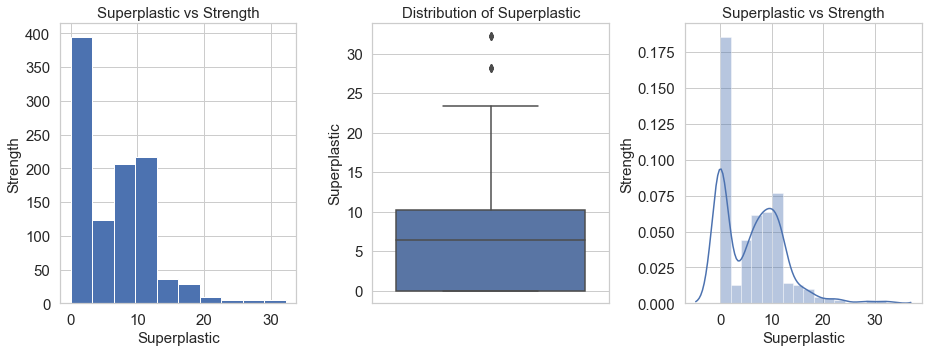

```python
fig, (ax1,ax2,ax3)=plt.subplots(1,3,figsize=(13,5))

#histogram
ax1.hist(concrete_df['superplastic'])
ax1.set_xlabel('Superplastic', fontsize=15)
ax1.set_ylabel('Strength', fontsize=15)
ax1.set_title('Superplastic vs Strength', fontsize=15)
ax1.tick_params(labelsize=15)

#boxplot
sns.boxplot(x='superplastic',data=concrete_df,orient='v',ax=ax2)
ax2.set_ylabel('Superplastic', fontsize=15)
ax2.set_title('Distribution of Superplastic', fontsize=15)
ax2.tick_params(labelsize=15)

#distplot
sns.distplot(concrete_df['superplastic'],ax=ax3)
ax3.set_xlabel('Superplastic', fontsize=15)
ax3.set_ylabel('Strength', fontsize=15)
ax3.set_title('Superplastic vs Strength', fontsize=15)
ax3.tick_params(labelsize=15)

plt.subplots_adjust(wspace=0.5)
plt.tight_layout()
```

### Fineagg

```python
# Range of values of Attribute Fineagg
print('Range of values for Attribute Fineagg: ', concrete_df['fineagg'].max()-concrete_df['fineagg'].min())
```

```
Range of values for Attribute Fineagg:  398.6
```

```python
# Central Values of the Attribute 'Fineagg' is indicated by the 5-Point Summary.
concrete_df['fineagg'].describe()
```

```
count    1030.000000
mean      773.580485
std        80.175980
min       594.000000
25%       730.950000
50%       779.500000
75%       824.000000
max       992.600000
Name: fineagg, dtype: float64
```

```python
# Quartiles of Attribute Fineagg
Q1=concrete_df['fineagg'].quantile(0.25)
Q3=concrete_df['fineagg'].quantile(0.75)
print('1st Quartile (Q1) is: ', Q1)
print('3st Quartile (Q3) is: ', Q3)
print('Interquartile range (IQR) is ', Q3-Q1)
```

```
1st Quartile (Q1) is:  730.9499999999999
3st Quartile (Q3) is:  824.0
Interquartile range (IQR) is  93.05000000000007
```

```python
# Outlier detection of Attribute Fineagg from Interquartile range (IQR)
# IQR=Q3-Q1
#lower 1.5*IQR whisker i.e Q1-1.5*IQR
#upper 1.5*IQR whisker i.e Q3+1.5*IQR
L1 = Q1-1.5*(Q3-Q1)
U1 = Q3+1.5*(Q3-Q1)
print('Upper outlier in Fineagg(U1): ', U1)
print('Lower outlier in Fineagg(L1): ', L1)
print('Number of outliers in Fineagg above U1 : ', concrete_df[concrete_df['fineagg'] > 963.75]['fineagg'].count())
print('Number of outliers in Fineagg below L1 : ', concrete_df[concrete_df['fineagg'] < 591.375]['fineagg'].count())
print('% of Upper Outliers: ',round(concrete_df[concrete_df['fineagg'] > 963.75]['fineagg'].count()*100/len(concrete_df)), '%')
print('% of Lower Outliers:',round(concrete_df[concrete_df['fineagg'] < 591.375]['fineagg'].count()*100/len(concrete_df)), '%')
```

```
Upper outlier in Fineagg(U1):  963.575
Lower outlier in Fineagg(L1):  591.3749999999998
Number of outliers in Fineagg above U1 :  5
Number of outliers in Fineagg below L1 :  0
% of Upper Outliers:  0.0 %
% of Lower Outliers: 0.0 %
```

```python
# Analyzing the Univariate distribution of Fineagg, quartiles, whiskers, any outliers present and
# target value distribution of Finaeagg vs strength.
```

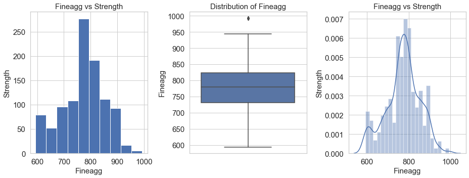

```python
fig, (ax1,ax2,ax3)=plt.subplots(1,3,figsize=(13,5))

#histogram
ax1.hist(concrete_df['fineagg'])
ax1.set_xlabel('Fineagg', fontsize=15)
ax1.set_ylabel('Strength', fontsize=15)
ax1.set_title('Fineagg vs Strength', fontsize=15)
ax1.tick_params(labelsize=15)

#boxplot
sns.boxplot(x='fineagg',data=concrete_df,orient='v',ax=ax2)
ax2.set_ylabel('Fineagg', fontsize=15)
ax2.set_title('Distribution of Fineagg', fontsize=15)
ax2.tick_params(labelsize=15)

#distplot
sns.distplot(concrete_df['fineagg'],ax=ax3)
ax3.set_xlabel('Fineagg', fontsize=15)
ax3.set_ylabel('Strength', fontsize=15)
ax3.set_title('Fineagg vs Strength', fontsize=15)
ax3.tick_params(labelsize=15)

plt.subplots_adjust(wspace=0.5)
plt.tight_layout()
```

### Age

```python
# Range of values of Attribute Age
print('Range of values for Attribute Age:', concrete_df['age'].max() - concrete_df['age'].min())
```

```
Range of values for Attribute Age: 364
```

```python
# Central Values of the Attribute 'Age' is indicated by the 5-Point Summary.
concrete_df['age'].describe()
```

```
count    1030.000000
mean       45.662136
std        63.169912
min         1.000000
25%         7.000000
50%        28.000000
75%        56.000000
max       365.000000
Name: age, dtype: float64
```

```python
# Quartiles of Attribute Age
Q1=concrete_df['age'].quantile(0.25)
Q3=concrete_df['age'].quantile(0.75)
print('1st Quartile (Q1) is: ', Q1)
print('3st Quartile (Q3) is: ', Q3)
print('Interquartile range (IQR) is ', Q3-Q1)
```

```
1st Quartile (Q1) is:  7.0
3st Quartile (Q3) is:  56.0
Interquartile range (IQR) is  49.0
```

```python
# Outlier detection of Attribute Age from Interquartile range (IQR)
# IQR=Q3-Q1
#lower 1.5*IQR whisker i.e Q1-1.5*IQR
#upper 1.5*IQR whisker i.e Q3+1.5*IQR
L1 = Q1-1.5*(Q3-Q1)
U1 = Q3+1.5*(Q3-Q1)
print('Upper outlier in Age(U1): ', U1)
print('Lower outlier in Age(L1): ', L1)
print('Number of outliers in Age above U1 : ', concrete_df[concrete_df['age'] > 129.5]['age'].count())
print('Number of outliers in Age below L1 : ', concrete_df[concrete_df['age'] < -66.5]['age'].count())
print('% of Upper Outliers: ',round(concrete_df[concrete_df['age'] > 129.5]['age'].count()*100/len(concrete_df)), '%')
print('% of Lower Outliers:',round(concrete_df[concrete_df['age'] < -66.5]['age'].count()*100/len(concrete_df)), '%')
```

```
Upper outlier in Age(U1):  129.5
Lower outlier in Age(L1):  -66.5
Number of outliers in Age above U1 :  59
Number of outliers in Age below L1 :  0
% of Upper Outliers:  6.0 %
% of Lower Outliers: 0.0 %
```

```python
# Analyzing the Univariate distribution of Age, quartiles, whiskers, any outliers present and
# target value distribution of Age vs strength.
```

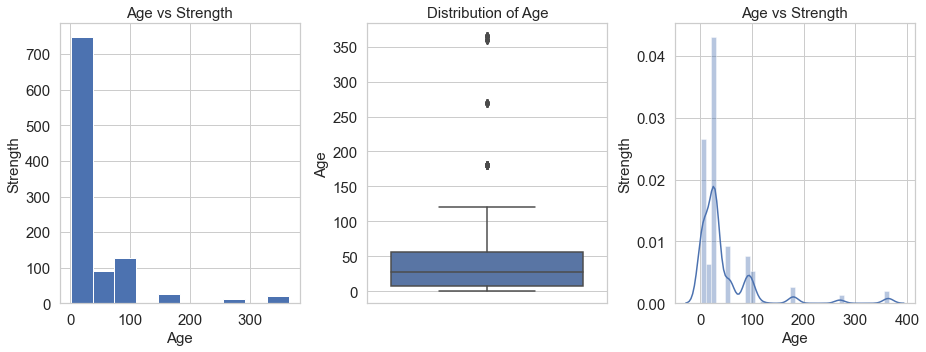

```python
fig, (ax1,ax2,ax3)=plt.subplots(1,3,figsize=(13,5))

#histogram
ax1.hist(concrete_df['age'])
ax1.set_xlabel('Age', fontsize=15)
ax1.set_ylabel('Strength', fontsize=15)
ax1.set_title('Age vs Strength', fontsize=15)
ax1.tick_params(labelsize=15)

#boxplot
sns.boxplot(x='age',data=concrete_df,orient='v',ax=ax2)
ax2.set_ylabel('Age', fontsize=15)
ax2.set_title('Distribution of Age', fontsize=15)
ax2.tick_params(labelsize=15)

#distplot
sns.distplot(concrete_df['age'],ax=ax3)
ax3.set_xlabel('Age', fontsize=15)
ax3.set_ylabel('Strength', fontsize=15)
ax3.set_title('Age vs Strength', fontsize=15)
ax3.tick_params(labelsize=15)

plt.subplots_adjust(wspace=0.5)
plt.tight_layout()
```

### UNIVARATE ANALYSIS OBSERVATIONS

Form the above Univariate analysis of Concrete mix dataset, we can observe the following:

1. cement is almost normal.
2. slag has three gausssians and rightly skewed.
3. ash has two gaussians and rightly skewed.
4. water has three guassians and slighly left skewed.
5. superplastic has two gaussians and rightly skewed.
6. coarseagg has three guassians and almost normal.
7. fineagg has almost two guassians and looks like normal.
8. age has multiple guassians and rightly skewed.

### b. BIVARIATE ANALYSIS

We will study the distribution between the predictor variables and target column using scatterplot and pairplot since all of them are numerical and continuous attributes.

#### i) Scatterplot - Predictor variables vs Strength

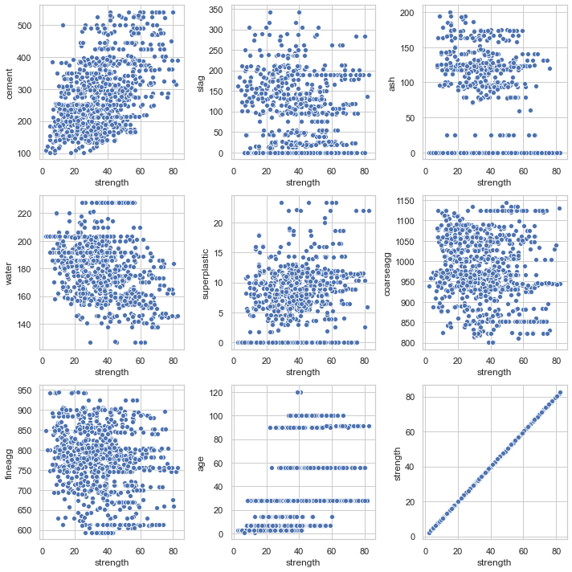

```python
fig,axes=plt.subplots(3,3,figsize=(10,10))
axes=axes.flatten()

for j in range(0,len(concrete_df.columns)):
    sns.scatterplot(data=concrete_df, x='strength', y=concrete_df.iloc[:,j], ax=axes[j])
plt.tight_layout()
plt.show()
```

#### ii) Pairplot - Study pairwise relationships in Concrete dataset

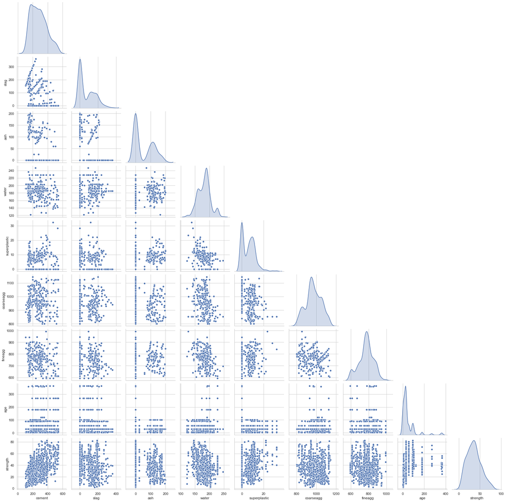

```python
sns.pairplot(concrete_df, diag_kind="kde",corner='True')
```

#### ii) Correlation Analaysis (Study of All Variabale and their Relationships)

```python
# Determing the pairwise correlation of all attributes in Concrete dataset
concrete_df.corr()
```

|  | cement | slag | ash | water | superplastic | coarseagg | fineagg | age | strength |
| --- | --- | --- | --- | --- | --- | --- | --- | --- | --- |
| cement | 1.000000 | -0.275216 | -0.397467 | -0.081587 | 0.092386 | -0.109349 | -0.222718 | 0.081946 | 0.497832 |
| slag | -0.275216 | 1.000000 | -0.323580 | 0.107252 | 0.043270 | -0.283999 | -0.281603 | -0.044246 | 0.134829 |
| ash | -0.397467 | -0.323580 | 1.000000 | -0.256984 | 0.377503 | -0.009961 | 0.079108 | -0.154371 | -0.105755 |
| water | -0.081587 | 0.107252 | -0.256984 | 1.000000 | -0.657533 | -0.182294 | -0.450661 | 0.277618 | -0.289633 |
| superplastic | 0.092386 | 0.043270 | 0.377503 | -0.657533 | 1.000000 | -0.265999 | 0.222691 | -0.192700 | 0.366079 |
| coarseagg | -0.109349 | -0.283999 | -0.009961 | -0.182294 | -0.265999 | 1.000000 | -0.178481 | -0.003016 | -0.164935 |
| fineagg | -0.222718 | -0.281603 | 0.079108 | -0.450661 | 0.222691 | -0.178481 | 1.000000 | -0.156095 | -0.167241 |
| age | 0.081946 | -0.044246 | -0.154371 | 0.277618 | -0.192700 | -0.003016 | -0.156095 | 1.000000 | 0.328873 |
| strength | 0.497832 | 0.134829 | -0.105755 | -0.289633 | 0.366079 | -0.164935 | -0.167241 | 0.328873 | 1.000000 |

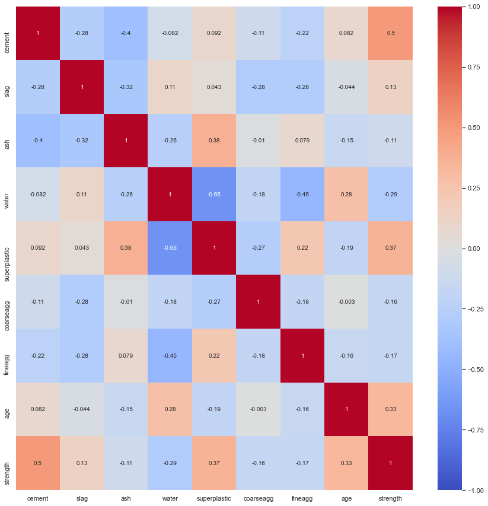

```python
# Finding the Pairwise Correlation with heat map
corr = concrete_df.corr()
plt.figure(figsize = (15,15))
sns.heatmap(concrete_df.corr(), annot = True, vmin = -1, vmax = 1, center = 0, cmap="coolwarm")
```

### BIVARIATE ANALYSIS OBSERVATIONS

Form the above analysis of Concrete mix dataset using Scatterplot, Correlation scores and Correlation heatmaps, we can observe the following:

#### ii) Slag vs other independent attributes:

Slag does not have any significant relation with ash, water, superplatic, coarseagg,fineagg and age. It almost spread like a cloud adn dispersed and has an insignifcant correlation value.  
It has a positive but weak correlation with Strength and thus a very weak predictor.

#### iii) Ash vs other independent attributes:

Ash does not have any significant relation with water, superplatic, coarseagg,fineagg and age. It's almost spread like a cloud and has an insignifcant correlation value.  
It has a negative and weak correlation with Strength and thus a very weak predictor.

#### iv) Water vs other independent attributes:

Water seems to have a negative linear relationship with superplastic and fineagg. It does not have any significant relationship with other independent atributes. This is true as Superplasticizers allows the reduction of water in the concrete upto the extent of 30% without reducing the workability.  
It has a negative and weak correlation with Strength and thus a very weak predictor.

#### v) Superplastic vs other independent attributes:

Superplastic has a negative linear relationship with water. It does not have any significant relationship with other independent attributes.  
It has a positive but weak correlation with Strength and thus a weak predictor.

#### vi) Coarseagg vs other independent attributes:

Coarseagg is negatively correlated to all other independent attributes but does not have a strong correlation. Its dispersed and spread like a cloud, r-value is insignificant.  
It has a negative but weak correlation with Strength and thus a weak predictor.

#### viii) Age vs other independent attributes:

Age does not have any relation to any other independent attribute.  
It has a positive but weak correlation with Strength and thus not a very strong predictor.

### c. OUTLIER DETECTION AND IMPUTATION

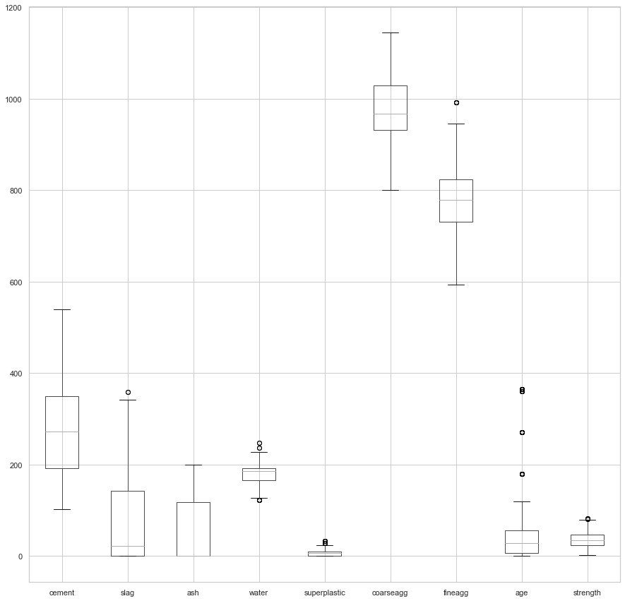

```python
concrete_df.boxplot(figsize=(15,15))
```

From the Box plot above and Univariate Analysis conducted earlier, we can conclude that:

Number of outliers in cement: 0

Number of outliers in ash: 0

Number of outliers in superplastic: 10

Number of outliers in coarseagg: 0

```python
# Make a copy of the Original Dataset prior to Treatment for Outliers
concrete_df1 = concrete_df
```

```python
# Outlier Imputatuion using Median
#Replacing the outliers by median

for col_name in concrete_df1.columns[:-1]:
    q1 = concrete_df1[col_name].quantile(0.25)
    q3 = concrete_df1[col_name].quantile(0.75)
    iqr = q3 - q1
    low = q1-1.5*iqr
    high = q3+1.5*iqr
    concrete_df1.loc[(concrete_df1[col_name] < low) | (concrete_df1[col_name] > high), col_name] = concrete_df1[col_name].median()
```

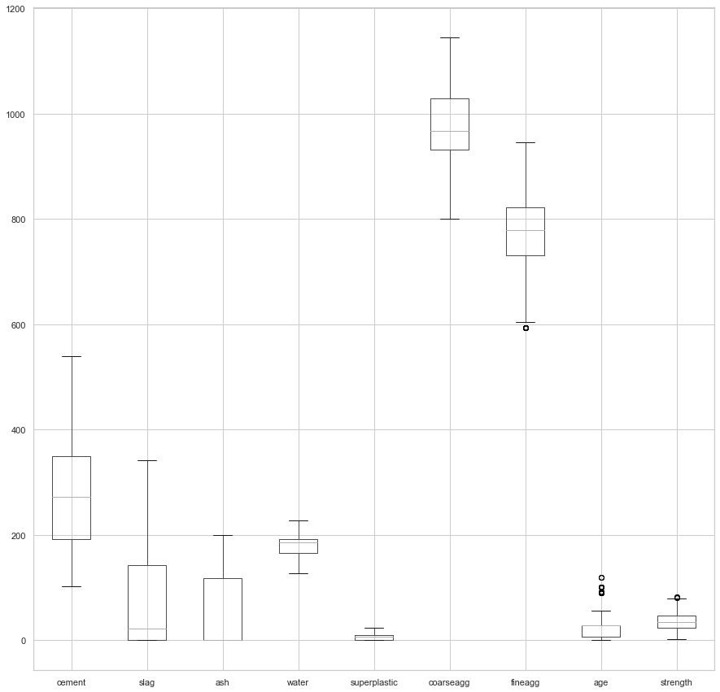

```python
concrete_df1.boxplot(figsize=(15,15))
```

```python
#After Outlier treatment, we observe above that the number of outliers and skewness of data is greatly reduced.
```